# Broadband Effect on Education

Daniel Lee, Hanna Lee, John Nguyen, Nick Vaughn

2/15/2022

# Report

## Proposal

### Abstract

We are concerned with inequity in students having broadband access because it may disadvantage many students as education relies more on technology. To address this concern, we plan to analyze multiple datasets on student state assessment performance in Washington and see if there is a correlation between their performance and broadband access.

### Keywords

1. Broadband
2. Equitable Education
3. Accessibility

### Introduction

Education is fundamental to our growth whether it’s done in a classroom setting or in our homes. As our society gravitates towards a technology-based empire, broadband must grow with our needs to prevent unbalanced progress. During the pandemic, this was highlighted when children were left to study at restaurants and parking lots with free Wi-Fi. The prevalent imbalance showcased the privilege of having expendable income for broadband and having access to reliable broadband. Our primary focus is on students and their academic status in the school year 2016-17, and our broadband data is from 2016. We will analyze broadband access within the different geographic areas within the US and see if there’s a correlation between student academic growth and broadband access.

### Design Situation

- **Project Framing**:

  Education enables individuals to build more prosperous lives and societies to achieve economic prosperity. In the modern world, education is closely intertwined with the Internet. The Internet enhances the educational experience in innumerable ways: it provides a wealth of information, increases opportunities for learning, and provides powerful tools to support the learning experience (Internet Society, 2017).

  However, the Internet’s educational benefits inherently create a disparity between students who have Internet access and those who do not. Not every student has equal access to the Internet. While an impressive 99 percent of US public schools have access to the Internet (NCES, n.d.), many developing nations struggle to provide even a traditional classroom education. In his book Outliers, author Malcolm Gladwell describes the biblically eponymous “Matthew Effect”- advantages compound gains while disadvantages compound losses (Gwinn, 2008). In the same vein, students with Internet access will further their education, while those with minimal access will fall behind. This snowball effect can widen social and economic disparities amongst nations, social classes, and other groups.
- **Human Values:**:
  - *Equality*:

    The Internet’s disparate impact on education is fundamentally a matter of equality. Varying levels of Internet access inherently create unequal learning environments, which results in unequal future opportunities. The main goal is to bridge this educational gap.
  - *Opportunity / Well-being*:

    Students with minimal access to the Internet are likely to have worse educational experiences and thus lesser future opportunities than their peers. We should aspire to provide them the opportunity to have an Internet-based education.
  - *Value Tensions*:

    In order to seek equality in education, we should ideally provide opportunities to students with minimal Internet access. However, it is possible to seek equality in the opposite direction - by denying the Internet from students currently utilizing it. This may result in more equality, but lessen opportunities for the bereft students and compromise their well-being.
- **Direct Stakeholders:**
  - *Educational Institutions*:

    Educational institutions are ultimately responsible for providing their students the best education possible. If data unequivocally proves that Internet access is indispensable to a superb education, they will be incentivized to provide Internet access to their students.
  - *Education Rights Groups*:

    These organizations have a mission to make education accessible. If a lack of Internet access renders traditional education obsolete, then these organizations will strive to make Internet-based education accessible.
- **Indirect Stakeholders:**
  - *Underprivileged Students*: Internet access will improve their quality of education and provide better future opportunities.
  - *Society*: If Internet access bolsters more students’ education, then economic output will increase in the long run.
  - *Families*: They would be able to see one their own members receive quality education.
  - *Privileged students*: If other students are granted an Internet-based education, this may increase academic competition for the incumbent privileged students.
- **Benefits:**
  1. We may establish equality in education and welfare amongst people.
  2. We can create more educated citizens, which in turn will lead to increased economic output and a more well-functioning society in the long run.
- **Harms:**
  1. While Internet access would provide opportunities to underprivileged students, the incumbent privileged students would likely suffer from higher competition.
  2. Organizations may decide to limit Internet access to students who already have it. This is fairly easy to implement since it involves taking resources away rather than providing them. However, this would harm the education of students already benefiting from Internet access and may indirectly impact society as a whole.

### Research Questions

1. Does limited broadband access impact on test satisfactory levels?
2. Is broadband access a factor in the different test subject performance?
3. Does English as a second language students performance differ based on broadband speeds?

### The Dataset

- **Report Card Assessment Data 2016-2017 School Year**
  - 951,000 observations and 30 variables
  - We have student state assessment data of various subjects from kindergarten to 12th grade.
  - The dataset has multiple identifiers for schools, breakdown of student demographics, different subjects, expected outcomes, and actual standing (satisfactory/unsatisfactory) of student grade/group.
  - Age of student group and various test scores were left out. Instead the dataset categorized the students as satisfactory or unsatisfactory in the subject matter
  - Washington Office of Superintendent of Public Instruction created the dataset on September 12, 2019. They own and update the dataset according to data.gov.
  - Educators and any field can make money off student data because they can create supplemental resources if they find students facing difficulties in certain subjects and tailor it to the students groups/grade having the issue.
  - The data is housed and hosted on a government website which provides added protection. The validity of the data is through direct student information data, so we confident in the outcomes.
  - We found this dataset through Data.gov. The citation is listed in references.
- **June 2016 FCC Area Table**
  - 178,992 observations and 7 variables
  - The dataset shows the broadband coverage in geographic areas throughout the country.
  - Each observation reveals the type of area, ID of area, the technology of broadband, urban/rural, tribal/nontribal, download speeds, and the number of providers. We don’t see the average price or who the providers are.
  - It is unclear who collected the data, but the owner is Humza Riaz. It was created on March 18, 2018 and reveals the general broadband accessibility in this country.
    - This is raw data from the FCC’s broadband website which has an interactive map feature that tracks various points of broadband usage in the country.
    - The origin of funding is unclear, but FCC is part of the federal government.
    - This data can allow for greater accessibility to broadband or highlight price gouging to users in rural areas.
  - The data was collected through surveys and public broadband information. It is credible since it’s reporting hard data, but surveys are never 100%.
  - We found this dataset through Data.gov. The citation is listed in references.
- **2020 FCC Geography Lookup**
  - 22,514,373 observations and 10 variables
  - This was our reference guide for the FCC Area Table because the ID of Area was coded as a number.
  - Since this was our decoder and only stated the longitude, latitude, and name of the area, we did not question the validity of the data.
  - The table was updated on April 8, 2021.
  - We found this dataset through Data.gov. The citation is listed in references.

### Expected Implications

In the history of education, having access to the internet has never been so critical. Teachers are increasingly turning to cloud-based learning management systems, such as Canvas, for the purpose of delivering and collecting assignments. This puts students without reliable access to the internet at a serious disadvantage. Not only are they unable to submit deliverables, but they also lack access to other online learning resources such as YouTube and Khan Academy. Broadband programs that provide students with a reliable internet connection can be funded by the government to address this inequity issue in education. Internet providers that want to invest in the future can offer students discounts on certain speeds. Internet companies can also upgrade or replace fiber optic cables in certain areas to improve broadband speed.

### Limitations

Our dataset of the performances of students by location is from 2016, and technology and its use in education has changed a lot since then, especially with the move to online education from the COVID pandemic. This posses a limitation, as the presence or extent of the disparity in education between areas based on broadband access may not be seen. This may be addressed by finding more data, but it may be something that we have to accept and address in our report. Another limitation is the measurement of quality of education. Our data uses standardized testing, which although standard, may not accurately measure the performance of students and the quality of their education. Additionally, any trend between broadband access and education may be due to correlation rather than causation. Areas with more broadband access are likely to be wealthier and more urban, thus are likely to also have a higher budget for schooling. This means areas with greater access may have better performance in education due to better textbooks and teachers rather than their access to the internet.

### Acknowledgements

We recognize Local Point for giving us our code name and selling overpriced food that prompted us to examine the notion of accessibility.

### References

Gwinn, M. A. (2008, November 12). Malcolm Gladwell dissects success in “Outliers”. The Seattle Times. Retrieved February 4, 2022, from https://www.seattletimes.com/entertainment/books/malcolm-gladwell-dissects-success-in-outliers/

Internet Access and Education: Key considerations for policy makers. Internet Society. (2017, November 20). Retrieved February 4, 2022, from https://www.internetsociety.org/resources/doc/2017/internet-access-and-education/

OSPI. (2019). Report Card Assessment Data 2016-17 School Year [CSV]. Retrieved from https://data.wa.gov/Education/Report-Card-Assessment-Data-2016-17-School-Year/5tvk-w2c5

Riaz, Humza. (2018). Area Table June2016 [CSV]. Retrieved from https://opendata.fcc.gov/Wireline/Area-Table-June2016/nb5q-gkcn

Riaz, Humza. (2019). Geography Lookup Table [CSV]. Retrieved from https://opendata.fcc.gov/Wireline/Geography-Lookup-Table/v5vt-e7vw

School Connectivity. National Center for Education Statistics. (n.d.). Retrieved February 4, 2022, from https://nces.ed.gov/pubs2002/internet/3.asp

### Appendix A:

No questions at this time.

## Summary Statistics

Below are a few summary statistics from our dataset.  
Medium Internet speed is considered to be at least 100 Mbps.  
Majority is considered to be over 50 percent.

**2)** The mean proportion of students who met test standards in counties where the majority of the population have / don’t have at least two points of Internet access and medium Internet speed are **0.49** and **0.48** respectively.

**3)** The mean proportion of low income students who met test standards in counties where the majority of the population have / don’t have at least medium Internet speed are **0.5** and **0.46** respectively.

## Agggregate Table

| County | Population_with_medium_speed | Mean_student_prop_met_standard |
| --- | --- | --- |
| Ferry | 1.00 | 0.38 |
| Franklin | 1.00 | 0.33 |
| Pend Oreille | 1.00 | 0.55 |
| Walla Walla | 1.00 | 0.40 |
| Stevens | 0.99 | 0.50 |
| Columbia | 0.97 | 0.52 |
| King | 0.97 | 0.53 |
| Benton | 0.96 | 0.43 |
| Island | 0.96 | 0.51 |
| Kitsap | 0.96 | 0.54 |
| Pierce | 0.96 | 0.49 |
| Snohomish | 0.94 | 0.50 |
| Asotin | 0.93 | 0.54 |
| Adams | 0.92 | 0.39 |
| Clark | 0.92 | 0.49 |
| Cowlitz | 0.92 | 0.45 |
| Thurston | 0.92 | 0.55 |
| Spokane | 0.90 | 0.53 |
| Skagit | 0.89 | 0.47 |
| Whatcom | 0.89 | 0.50 |
| Chelan | 0.85 | 0.44 |
| Grant | 0.82 | 0.36 |
| Grays Harbor | 0.78 | 0.41 |
| Jefferson | 0.76 | 0.42 |
| Mason | 0.76 | 0.41 |
| Clallam | 0.73 | 0.48 |
| Douglas | 0.71 | 0.39 |
| Lewis | 0.70 | 0.48 |
| Okanogan | 0.43 | 0.43 |
| Skamania | 0.38 | 0.40 |
| Pacific | 0.32 | 0.52 |
| San Juan | 0.25 | 0.63 |
| Garfield | 0.12 | 0.56 |
| Kittitas | 0.06 | 0.48 |
| Whitman | 0.05 | 0.63 |
| Yakima | 0.04 | 0.34 |
| Klickitat | 0.02 | 0.51 |
| Wahkiakum | 0.01 | 0.53 |
| Lincoln | 0.00 | 0.62 |

This is an aggregate table that shows by Washington counties, **1)** the population proportion with at least medium Internet speed (100 Mbps) and **2)** the mean proportion of students who met test standards. If you are a Washington resident, you may take interest in noting the different statistics for different counties. The table gives a quick look at the correlation between the two variables, and potentially the impact of Internet speed on education. You may notice from the first row that everyone having at least medium Internet speed does not necessarily guarantee high proportions of educational success.

## Chart #1

### Speed and Education

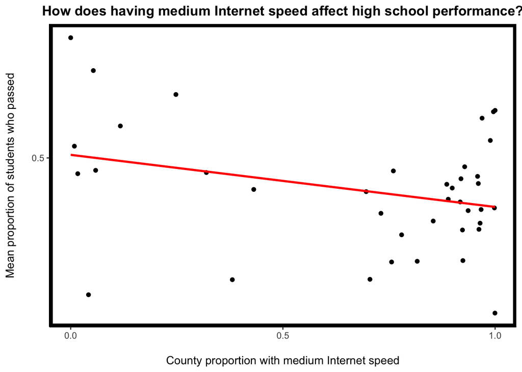

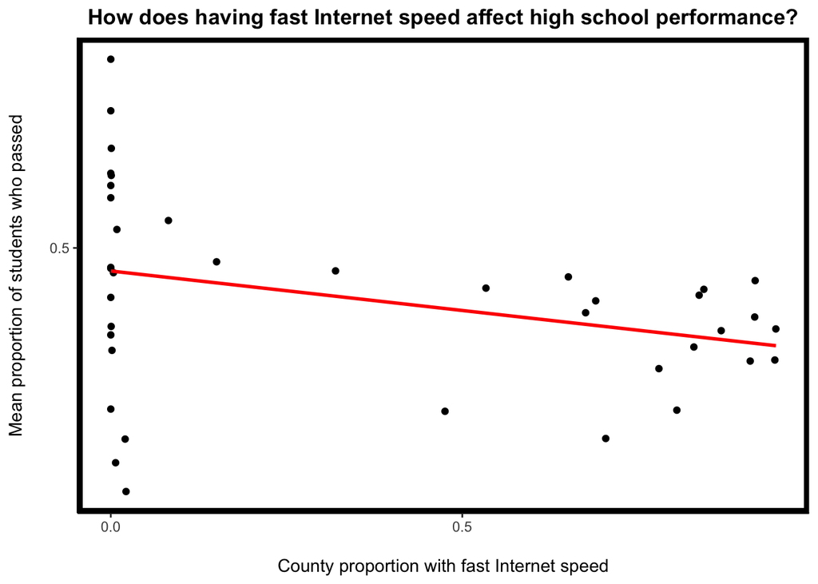

These scatter plots attempt to roughly illustrate the impact that Internet speed has on the quality of education. Specifically, it measures the correlation between **1)** the population proportion of each county that has at least medium (100Mbps)/ fast level (250Mbps) Internet speed to **2)** the mean proportion of high school students who met test standards. Most counties seem to have a high population proportion with at least medium Internet access, while most have either a high or low population proportion with at least fast Internet access.

Both graphs show a slightly negatively sloped linear regression line, which would indicate that the higher the population proportion with medium / fast Internet speed, the less students meet the test standards. This can loosely imply that better Internet speed does not result in better education. However, correlation does not imply causation, and so further tests would be required. Moreover, if you remove a couple of outliers towards the top left of the graph, the regression line would probably be positively sloped.

### Access Points and Education

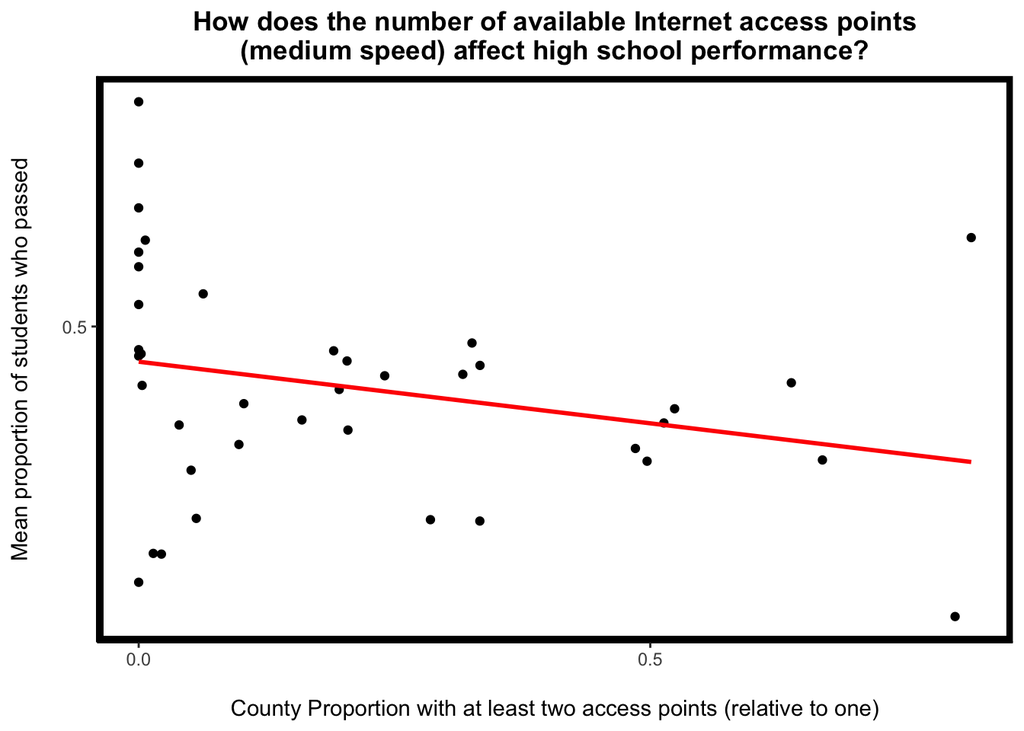

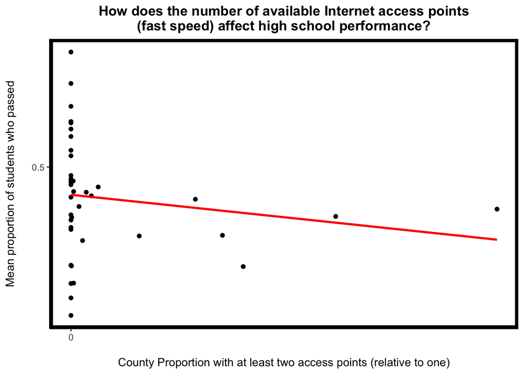

Both graphs show a slightly negatively sloped linear regression line, which would indicate that the higher the population proportion with at least two access points (relative to one), the less students meet test standards. This can loosely imply that more Internet access points does not result in better education. However, correlation does not imply causation, and so further tests would be required. Moreover, if you remove some points, the graph appears it could have a positively sloped regression line.

## Chart #2

### Broadband Access and Education

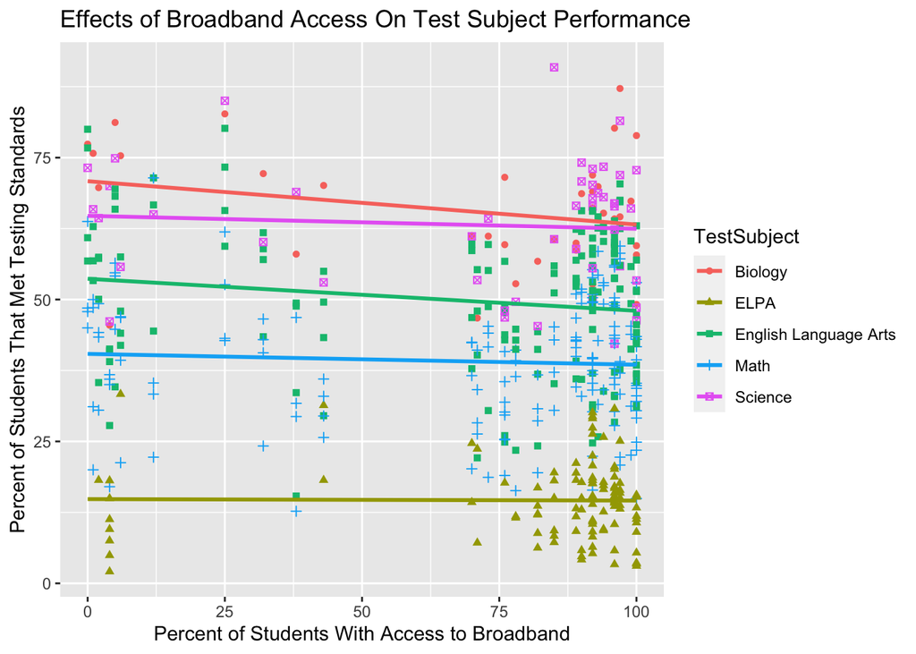

**Purpose**

One of the reasons why we wanted to conduct this research was to determine the potential effects of broadband access on student academic performance. This chart shows the correlation between the percentage of students who have access to acceptable broadband and the percentage of those students who meet testing standards.

**Observations and Insights**

Based on our chart, there seems to be a negative correlation between broadband access and student academic performance. We anticipated higher percentages of broadband access to correlate with higher percentage of students meeting testing standards. Our chart, however, tells us otherwise. With the datasets that we have used, we are unable to conclude whether or not there is correlation between broadband access and student performance.

## Chart #3

### Middle School English Lanuage Leaners and 0/1 Broadband Access

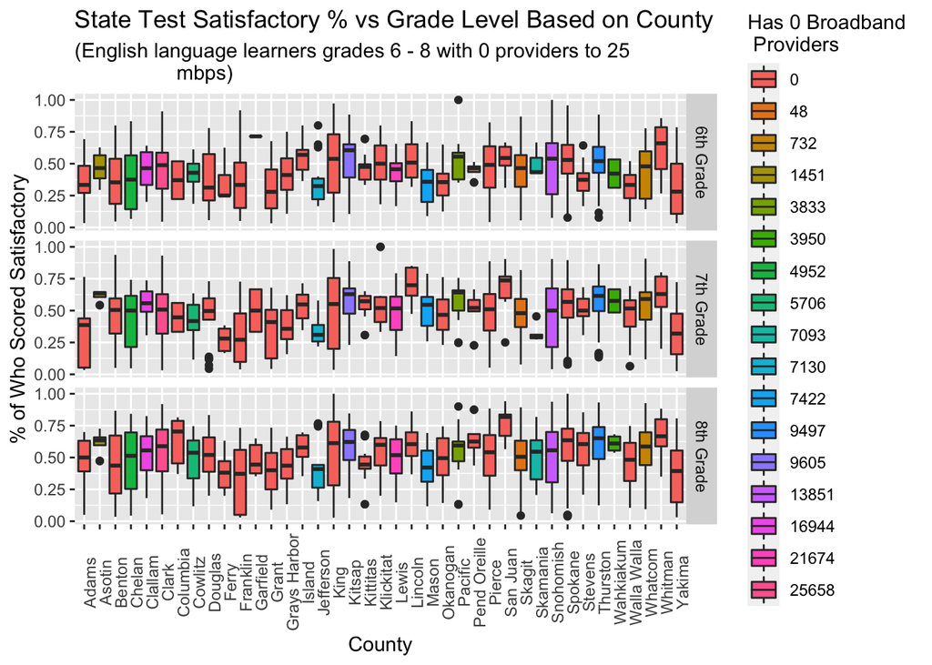

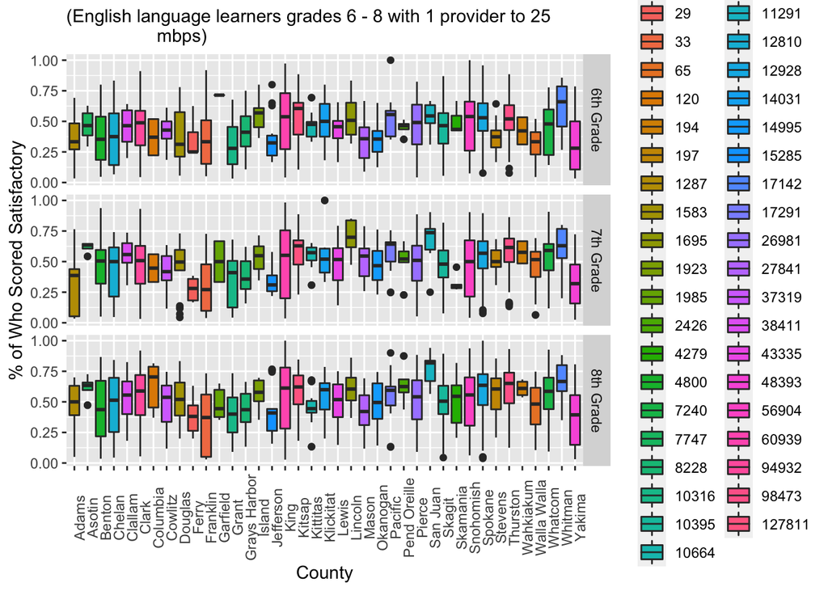

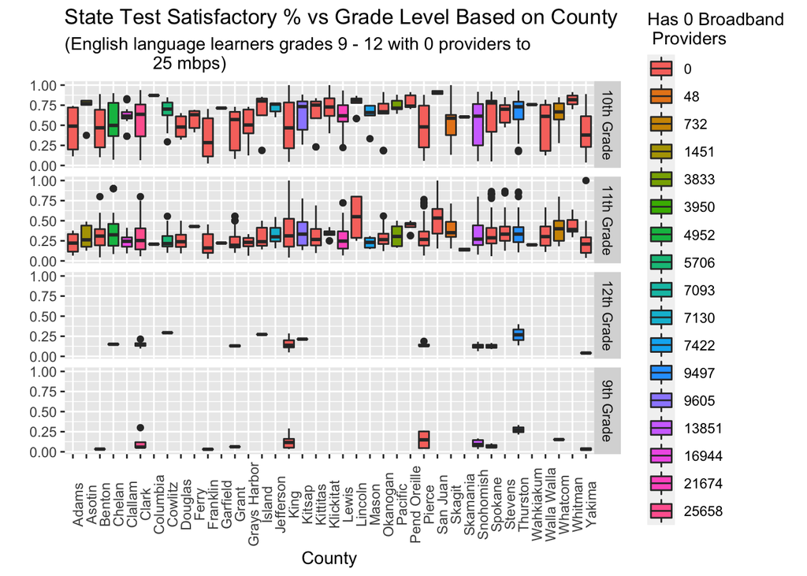

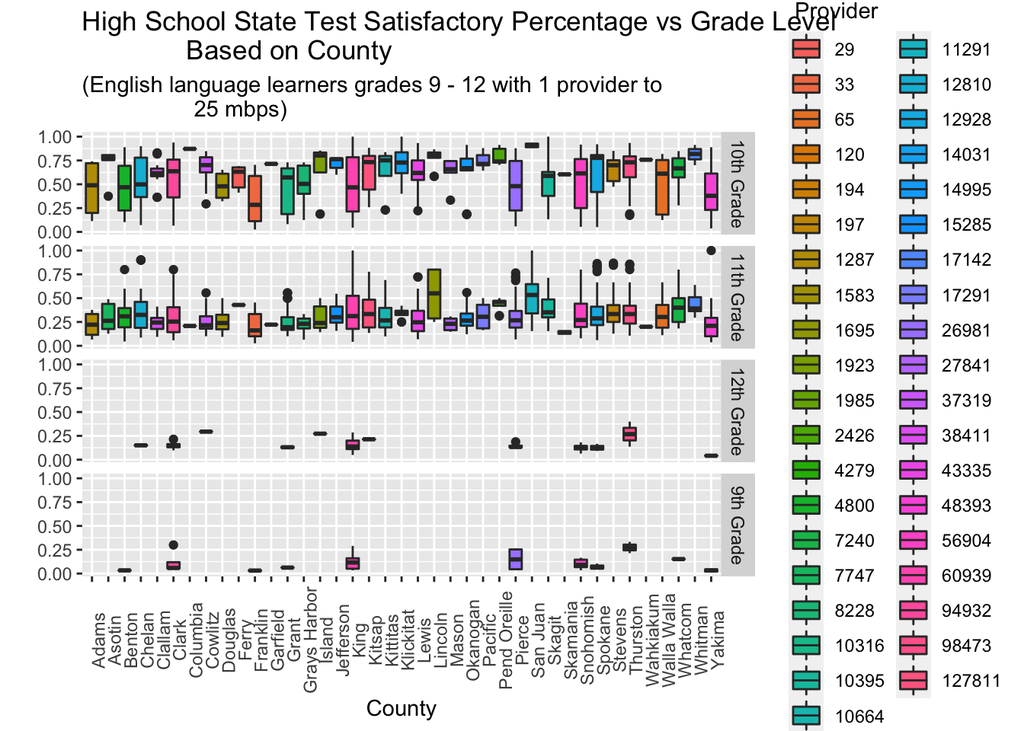

**Purpose**

Due to language barrier, we wanted to observe how those students’ academics were impacted by broadband access. In our digital age, our education is moving towards online research, homework, and resources. Navigating our academic system is hard enough for non-English speakers, and if they don’t have access to broadband, it’ll can push them farther behind. Therefore, we want to explore the impact broadband had on English learners. For this analysis, the definition of broadband is 1 provider and having at least 25 mbps.

**Observations and Insights**

For easier analysis, the data is broken down between middle and high school students. From there, we see satisfactory percentage in each county based on having a broadband provider. With middle school students, the correlation between broadband access and having a satisfactory grade on the state test is negligible. We do have outliers in some counties, and if we discount those, we do see slight upticks in counties that have broadband access vs. those who do not have access. Not surprisingly, King county had one of the highest maximum satisfactory percentages.

The impact of broadband was shown by the color change between 0 providers to 1 provider. If there was a color change, we would compare the 2 areas. If there was an increase in the amount of people that had providers, we would see that there was a stronger broadband presence in the area and the satisfactory percentage would be evaluated.